# 2 - General presentation

Théo Tacail

2021-09-07

[Full documentation and tutorials can be found on the isobxr website.](https://ttacail.github.io/isobxr_web/)

The [isobxr](https://ttacail.github.io/isobxr/) package is a set of R tools designed to perform and explore stable isotope box modelling of open or closed systems. It provides a ready-to-use tool allowing users to develop and test isotopic box models of their system of interest. It allows the user to explore the behavior of these systems in both static (*e.g.*, at steady state) or dynamic modes (*e.g.*, in reaction to a perturbation), build complex scenarios, and sweep the space of parameters in both static and dynamic modes.

# Introduction to isobxr approach

## Systems and modelling approach

The global definition of the systems considered for the stable isotope box modelling by [isobxr](https://ttacail.github.io/isobxr/) is presented in the cheatsheet below.

[figure not shown]

## Fundamental workflow

- `run_isobxr` is the main function of the [isobxr](https://ttacail.github.io/isobxr/) package.
- `run_isobxr` is used to perform single runs of stable isotope box models of all types of systems.
- The general workflow of the `run_isobxr` function is summarized in the cheatsheet below.

[figure not shown]

# Box modelling equations

In this section we present the mathematical formalism used in isobxr stable isotope box modelling.

The theory and formalism shown in this section is derived from the chapter 7 (*Dynamic systems*) of

: Albarède, F., 1995. Introduction to Geochemical Modelling. Cambridge University Press, Cambridge.  
https://doi.org/10.1017/CBO9780511622960

## Definitions

We consider a system consisting of $n$ boxes $j$, exchanging an element **X** that has at least two stable isotopes $M$ and $N$. Any box $i$ is defined by:

- $m^X_i$ the mass of element **X** in box $i$ - also referred to as **box size** thereafter
- $m^M_i$ and $m^N_i$ the masses of isotopes $M$ and $N$ in box $i$, respectively
- $J_{i \mapsto j}^X$ is the mass flux of **X** from $i$ to $j$ (homogeneous to a mass per time unit)

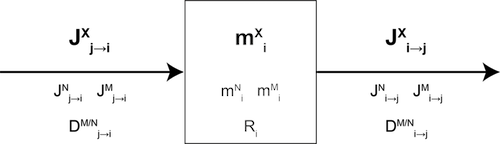

We call $R_i$ the $M/N$ isotope abundance ratio:
$$R_i = \left(\dfrac{n^M}{n^N}\right)_i = \left(\dfrac{m^M}{m^N}\right)_i \times \left(\dfrac{M^N}{M^M}\right) = \left(\dfrac{m^M}{m^N}\right)_i A$$
where

- $n^M_i$ and $n^N_i$ are the molar quantities of isotopes $M$ and $N$ in box $i$
- $M^M$ and $M^N$ are the molar masses of isotopes $M$ and $N$ in box $i$
- $A = \left(\frac{M^N}{M^M}\right)$ the ratio of the molar masses of $N$ and $M$.

Finally, we define $D_{i \mapsto j}^{M/N}$ the relative fractionation coefficient between M and N from $i$ to $j$:

$$D_{i \mapsto j}^{M/N} = \dfrac{{J_{i \mapsto j}^M}/{J_{i \mapsto j}^N}}{m^M_i/m^N_i}$$

The principle of modelling the system consists now in predicting the evolution of **box sizes** ($m^X_i$) during time and the evolution of the **isotope ratios** ($R_i$), knowing the fluxes, initial box sizes and fractionation coefficients.

## Mass conservation of element X

Considering **X** has **no radioactive nor radiogenic component**, mass conservation for element **X** reads :

$$\dfrac{dm^X_i}{dt} = - \sum \limits_{j\neq i} J_{i \mapsto j}^X + \sum \limits_{j\neq i} J_{j \mapsto i}^X$$

When considering constant fluxes, this equation can be integrated in its linear form as follows:

$$m^X_i = \left(- \sum \limits_{j\neq i} J_{i \mapsto j}^X + \sum \limits_{j\neq i} J_{j \mapsto i}^X\right) \times t + m^X_{i, t_0}$$

where $m^X_{i, t_0}$ is the mass of element **X** in box $i$ at t = 0.

## Differential equations

Considering $N$ and $M$ are stable and non radiogenic, mass conservation reads :

$$\dfrac{dm^N_i}{dt} = - \sum \limits_{j\neq i} J_{i \mapsto j}^N + \sum \limits_{j\neq i} J_{j \mapsto i}^N = - \sum \limits_{j\neq i} \dfrac{J_{i \mapsto j}^N}{m^N_i} m^N_i + \sum \limits_{j\neq i} \dfrac{J_{j \mapsto i}^N}{m^N_j} m^N_j$$

Likewise,

$$\dfrac{dm^M_i}{dt} = - \sum \limits_{j\neq i} \dfrac{J_{i \mapsto j}^M}{m^M_i} m^M_i + \sum \limits_{j\neq i} \dfrac{J_{j \mapsto i}^M}{m^M_j} m^M_j$$

We can meanwhile derive the ratio $R_i$ as :

$$\dfrac{dR_i}{dt} = \dfrac{d}{dt}\left(\dfrac{m^M}{m^N}\right)_i A = \dfrac{A}{{m^N_i}^2} \left(m^N_i\dfrac{dm^M_i}{dt} - m^M_i \dfrac{dm^N_i}{dt}\right) = \dfrac{A}{m^N_i} \left(\dfrac{dm^M_i}{dt} - \dfrac{R_i}{A} \dfrac{dm^N_i}{dt}\right)$$

We can insert mass conservation derivative into previous relationship:

$$\dfrac{dR_i}{dt} = \dfrac{A}{m^N_i} \left(- \sum \limits_{j\neq i} \dfrac{J_{i \mapsto j}^M}{m^M_i} m^M_i + \sum \limits_{j\neq i} \dfrac{J_{j \mapsto i}^M}{m^M_j} m^M_j + \dfrac{R_i}{A} \sum \limits_{j\neq i} \dfrac{J_{i \mapsto j}^N}{m^N_i} m^N_i - \dfrac{R_i}{A} \sum \limits_{j\neq i} \dfrac{J_{j \mapsto i}^N}{m^N_j} m^N_j \right)$$

Modified as such :

$$\dfrac{dR_i}{dt} = A \left(- \sum \limits_{j\neq i} \dfrac{J_{i \mapsto j}^M}{m^M_i} \dfrac{m^M_i}{m^N_i} + \sum \limits_{j\neq i} \dfrac{J_{j \mapsto i}^M}{m^M_j} \dfrac{m^M_j}{m^N_j} \dfrac{m^N_j}{m^N_i} + \dfrac{R_i}{A} \sum \limits_{j\neq i} \dfrac{J_{i \mapsto j}^N}{m^N_i} - \dfrac{R_i}{A} \sum \limits_{j\neq i} \dfrac{J_{j \mapsto i}^N}{m^N_j} \dfrac{m^N_j}{m^N_i} \right)$$

$$\dfrac{dR_i}{dt} = A \left(- \sum \limits_{j\neq i} \dfrac{J_{i \mapsto j}^M}{m^M_i} \dfrac{R_i}{A} + \sum \limits_{j\neq i} \dfrac{J_{j \mapsto i}^M}{m^M_j} \dfrac{R_j}{A} \dfrac{m^N_j}{m^N_i} + \dfrac{R_i}{A} \sum \limits_{j\neq i} \dfrac{J_{i \mapsto j}^N}{m^N_i} - \dfrac{R_i}{A} \sum \limits_{j\neq i} \dfrac{J_{j \mapsto i}^N}{m^N_j} \dfrac{m^N_j}{m^N_i} \right)$$

$$\dfrac{dR_i}{dt} = R_i \sum \limits_{j \neq i} \left(\dfrac{J^N_{i \mapsto j}}{m^N_i} - \dfrac{J^M_{i \mapsto j}}{m^M_i} \right) + \sum \limits_{j \neq i} \dfrac{J^M_{j \mapsto i}}{m^M_j} \dfrac{m^N_j}{m^N_i} R_j - \sum \limits_{j \neq i} \dfrac{J^N_{j \mapsto i}}{m^N_j} \dfrac{m^N_j}{m^N_i} R_i$$

$$\dfrac{dR_i}{dt} = R_i \sum \limits_{j \neq i} \left(\dfrac{J^N_{i \mapsto j}}{m^N_i} - \dfrac{J^M_{i \mapsto j}}{m^M_i} \right) +
\sum \limits_{j \neq i} \left( \dfrac{J^M_{j \mapsto i}}{m^M_j} R_j - \dfrac{J^N_{j \mapsto i}}{m^N_j} R_i \right) \dfrac{m^N_j}{m^N_i}$$

$$\dfrac{dR_i}{dt} =
R_i \sum \limits_{j \neq i} \dfrac{J_{i \mapsto j}^N}{m^N_i} \left(1- \dfrac{{J_{i \mapsto j}^M}/{J_{i \mapsto j}^N}}{{m^M_i}/{m^N_i}}\right) + \sum \limits_{j \neq i} \dfrac{J_{j \mapsto i}^N}{m^N_j} \left(\dfrac{{J_{j \mapsto i}^M}/{J_{j \mapsto i}^N}}{m^M_j / m^N_j} R_j - R_i \right) \dfrac{m^N_j}{m^N_i}$$

Resulting in :

$$\dfrac{dR_i}{dt} =
R_i \sum \limits_{j \neq i} \dfrac{J_{i \mapsto j}^N}{m^N_i} \left(1- D_{i \mapsto j}^{M/N} \right) + \sum \limits_{j \neq i} \dfrac{J_{j \mapsto i}^N}{m^N_j} \left(D_{j \mapsto i}^{M/N} R_j - R_i \right) \dfrac{m^N_j}{m^N_i}$$

In order to solve this equation, we assume that:

$$\begin{array}{ccccc}
\dfrac{J_{i \mapsto j}^N}{m^N_i} \simeq \dfrac{J_{i \mapsto j}^X}{m^X_i} & , &
\dfrac{J_{j \mapsto i}^N}{m^N_j} \simeq \dfrac{J_{j \mapsto i}^X}{m^X_j} & , &
\dfrac{m^N_j}{m^N_i} \simeq \dfrac{m^X_j}{m^X_i}
\end{array}$$

These assumptions are valid for amplitude of stable isotope fractionations of the order of tens of ‰.

These assumptions find their limitation in the case of ample stable isotope fractionations such as sometimes observed for isotopic systems of light elements (such as D/H). In these cases, the differences in reactivity can be too great and amplitudes of stable isotope fractionations too marked for the assumptions to be applicable.

We thus have the following **system of first order differential equations** used thereafter:

$$\dfrac{dR_i}{dt} =
R_i \sum \limits_{j \neq i} \dfrac{J_{i \mapsto j}^X}{m^X_i} \left(1- D_{i \mapsto j}^{M/N} \right) + \sum \limits_{j \neq i} \dfrac{J_{j \mapsto i}^X}{m^X_j} \left(D_{j \mapsto i}^{M/N} R_j - R_i \right) \dfrac{m^X_j}{m^X_i}$$

This system can be solved in order to reconstruct the evolution of stable isotope ratios $R_i(t)$ in each box over time.

Two main situations can be distinguished here.

1. **The inward and outward fluxes of element X for any given box are balanced**

   In this case, all box sizes ($m^X_i$) are constant, which means that ${dm^X_i}/{dt} = 0$ for all boxes.

   The reconstruction of $R_i(t)$ only requires the solving of the system of ordinary first order differential equations.

   This can be done analytically *via* the algebraic inversion of the equation system matrix. This is what the `ana_slvr` core functions does.
2. **The inward and outward fluxes of element X for at least one box is unbalanced**

   In this case, at least one box displays a varying mass of element **X** with time ($m^X_i(t)$) which means that ${dm^X_i}/{dt} \neq 0$ for at least one box.

   The reconstruction of $R_i(t)$ requires the simultaneous solving of the system of ordinary first order differential equations describing $R_i(t)$ and of the derivative of $m^X_i(t)$ (with a linear solution).

   This is performed numerically *via* an incremental integration as done by the `num_slvr` core function.

All $R_i(t)$ stable isotope ratios can be also expressed as $\delta_i(t)$ values expressed in the ‰ unit, defined as follows and where $R_{std}$ is the stable isotope ratio of the standard or reference material:

$$\delta^{M/N}X_i(t) = \left(\dfrac{R_i(t)}{R_{std}} - 1\right) \times 1000$$

# isobxr solvers

The [isobxr](https://ttacail.github.io/isobxr/) package uses two core solver functions to solve the system of differential equations: `num_slvr` and `ana_slvr`.

These functions are not intended to be directly called by users themselves, although this remains possible.

These functions are called within broader functions (e.g., `run_isobxr`).

Because these functions are the actual solvers of the stable isotope box model equation systems, you will find here a description of their functioning and applicability.

You can also refer to the documentation for these two functions by typing the following code into your R console:

```r
?ana_slvr
?num_slvr
```

## **INPUT** file

The **INPUT** file contains the set of commands required to run either `ana_slvr` or `num_slvr`.

Its format and name are standardized and should not be altered.

Its direct modification by user is not required because **INPUT** files are edited by the broader and user-friendly `run_isobxr` function, described in another section of this vignette.

### File name and format

- The **INPUT** file is a **Rda** file (R data format allowing to store multiple R objects)
- The **INPUT** file name has to end with the following: [ **IN.Rda** ].
- The **INPUT** file name structure is [ **RUN name + IN.Rda** ].
- *Example*: [ **this_is_a_run_name_IN.Rda** ]

### File content

The **INPUT** file contains at least the 4 following objects strictly named as follows:

1. **CONSTS_IN**: Dataframe documenting the constants
2. **INITIAL_IN**: Dataframe documenting the initial conditions of all box sizes (even empty ones) and all initial delta values.
3. **FLUXES_IN**: Dataframe documenting the mass fluxes of element X between all boxes (structured as a square matrix)
4. **COEFFS_IN**: Dataframe documenting the isotopic fractionation coefficients between all boxes (structured as a square matrix)

The **INPUT** file is an output from the `run_isobxr` function and does not require the user intervention.

## Numerical solver (**num_slvr**)

The numerical solver `num_slvr` iteratively integrates the derivatives of the box sizes ($\frac{dm^X_i}{dt}$) and isotope ratios ($\frac{dR_i}{dt}$) over the whole run duration.

The `num_slvr` uses the `ode` ordinary differential equation integrating function from the **deSolve** package.

### Applicability

This function solves the evolution of both the isotope ratios and the sizes of each box defined by user.

The `num_slvr` function therefore can be used in **two distinct cases**:

1. In the case of **balanced inward and outward fluxes** of element **X** between all involved boxes.

   The derivative of box sizes will be null ($\frac{dm^X_i}{dt} = 0$), in other words all box sizes will be constant.
2. In the case of **unbalanced inward and outward fluxes** of element **X** for at least one box of the system.

   The derivative of box sizes will be non null in at least one case ($\frac{dm^X_i}{dt} \neq 0$), in other words at least on box loses and accumulates the element X.

The drawbacks of this function is that

- Its accuracy depends on the time resolution of the run.
- The calculation can be time consuming.
- We miss information on the system dynamics, which an analytical solver could bring.

**The use of this function is thus preferred in the case of unbalanced fluxes**, where at least one box loses or accumulates the element **X** over time (case #2).

It then allows to study the dynamic responses of a system to a perturbation of the flux balance for at least one box.

### Using **num_slvr**

*Remark*: The direct use of `num_slvr` function by user is not intended because this function is integrated in the global `run_isobxr` function described thereafter.

- *Constants* (CONSTS_IN) defining the system (Element symbol, isotopes considered, standard or reference material isotope ratio, run duration and number of time steps)
- *Initial conditions* (INITIAL_IN) where each box is associated to an initial size (mass of element X) and an initial isotope composition expressed in delta value (‰ unit)
- A matrix *fluxes* (FLUXES_IN) of element **X** between all boxes of the system (in mass unit per time unit)
- A matrix of *isotope fractionation coefficients* (COEFFS_IN) associated to all boxes of the system

The `num_slvr` function returns the numerically determined evolution of the stable isotope ratios and masses of element **X** in all boxes over the run duration.

The `num_slvr` **OUTPUT** contains the following:

- OUT data file storing initial and final size and delta values in each box
- evS data file storing the evolution of the sizes (masses of element X) of each box
- evD data file storing the evolution of the delta values in each box

By default (save_run_outputs = FALSE), all **OUTPUT** data is stored in a temporary directory. If save_run_outputs = TRUE, the outputs are saved in the same directory as the input file.

By default, all **OUTPUT** data is saved in a **Rda** output file (**RUN name + OUT.Rda**).

The `num_slvr` function optionally allows user to edit the **OUTPUT** data as **csv** files stored in a DIGEST folder ([ **RUN name + DIGEST** ]) with the following name structures:

- OUT data: [ **out_1_N_OUT + RUN name + .csv** ]
- evS data: [ **out_2_N_evS + RUN name + .csv** ]
- evD data: [ **out_3_N_evD + RUN name + .csv** ]

## Analytical solver (**ana_slvr**)

The analytical solver `ana_slvr` calculates the analytical solutions of the system of ordinary differential equations (ODES) of stable isotope ratios for an element **X** in all boxes.

It determines the eigenvalues, eigenvectors and constants defined by initial conditions associated to the ODES, and allows to determine the functions that describe the evolution of stable isotope ratios as a function of time.

### Applicability

In this case, the box sizes are considered as constant because the solving of the system of differential equations only considers the isotope ratios as varying with time.

In other words, in the case of **balanced inward and outward fluxes** for all finite boxes ($\frac{dm^X_i}{dt} = 0$), this function allows to accurately determine the expression of the stable isotope ratio in a given box as a function of time.

The function also edits a dataset of the evolution of isotope compositions in each box over the time range, with the time resolution determined by the user.

The use of this function is thus **not applicable in the case of unbalanced fluxes** for one finite box or more.

However, the `ana_slvr` function can be used in balanced open systems, with boxes defined as infinite and unbalanced sources or sinks, as described in the model design section thereafter.

### Using **ana_slvr**

*Remark*: The direct use of `ana_slvr` function by user is not intended because this function is integrated in the global `run_isobxr` function described thereafter.

- *Constants* (CONSTS_IN) defining the system (Element symbol, isotopes considered, standard or reference material isotope ratio, run duration and number of time steps)
- *Initial conditions* (INITIAL_IN) where each box is associated to an initial size (mass of element X) and an initial isotope composition expressed in delta value (‰ unit)
- A matrix *fluxes* (FLUXES_IN) of element **X** between all boxes of the system (in mass unit per time unit)
- A matrix of *isotope fractionation coefficients* (COEFFS_IN) associated to all boxes of the system

The `ana_slvr` function returns the analytical solutions of the ODES which describes the stable isotope ratios in each box. The `ana_slvr` function also returns the evolution of the delta values in each box. (in ‰, relative to the reference material).

The `ana_slvr` **OUTPUT** contains the following:

- OUT data file storing initial and final size and delta values in each box
- ODE_SOLNs data file summarizing outputs of the analytical solutions of the ODES

  (eigenvalues, eigenvectors, relaxation times, constants according to initial conditions)
- evD data file storing the evolution of the delta values in each box

By default (save_run_outputs = FALSE), all **OUTPUT** data is stored in a temporary directory. If save_run_outputs = TRUE, the outputs are saved in the same directory as the input file.

By default, all **OUTPUT** data is saved in a **Rda** output file (**RUN name + OUT.Rda**).

The `ana_slvr` function optionally allows user to edit the **OUTPUT** data as **csv** files stored in a DIGEST folder ([ **RUN name + DIGEST** ]) with the following name structures:

- OUT data: [ **out_1_A_OUT + RUN name + .csv** ]
- ODE_SOLNs data: [ **out_2_A_ODE_SOLNs + RUN name + .csv** ]
- evD data: [ **out_3_A_evD + RUN name + .csv** ]